#### Hult International Business School

# Bike Rental Data Analysis

#### Introduction

Bay Wheels is a bike-sharing system that provides an efficient and eco-friendly transportation option across urban areas. With the growing adoption of sustainable travel, understanding user behavior is key to optimizing operations, improving customer experience, and increasing ridership. This analysis explores patterns in bike rentals based on time, weather, and holidays. The goal is to uncover actionable insights that can inform strategic planning. Using a dataset of over 1,300 records, we aim to determine what drives bike usage and how the company can leverage environmental and behavioral patterns to grow.

```python
import pandas as pd
import seaborn as sns
import matplotlib.pyplot as plt

# Load data from Excel file provided on the assignment
file_path = 'bikes_data.xlsx'
df = pd.read_excel(file_path, sheet_name='SU (2 + 3)')
```

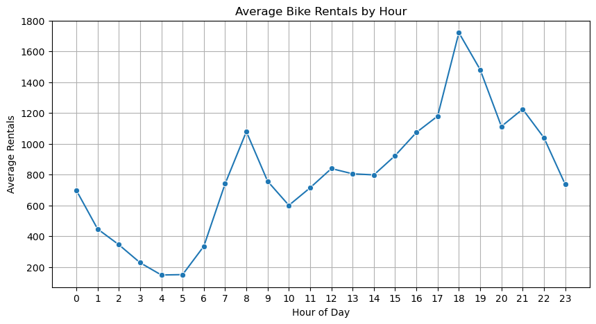

```python
# --- Visualization 1: Rental Volume by Hour ---
rentals_by_hour = df.groupby('Hour', observed=True)['RENTALS'].mean().reset_index()
plt.figure(figsize=(10, 5))
sns.lineplot(x='Hour', y='RENTALS', data=rentals_by_hour, marker='o')
plt.title('Average Bike Rentals by Hour')
plt.xlabel('Hour of Day')
plt.ylabel('Average Rentals')
plt.grid(True)
plt.xticks(range(0, 24))
plt.show()

# This visual shows peak rental times around morning and evening, indicating commuting behavior.
```

#### Rentals by Hour

This chart shows the average number of rentals for each hour of the day. The goal is to uncover the time blocks when rentals peak. Most users rent bikes during peak commute hours: 8 AM and 6 PM. This suggests the bikes are primarily used for work-related commuting. Knowing this allows the company to ensure bikes are restocked in high demand areas before these peak hours begin. Understanding demand flow by time can also improve predictive maintenance scheduling and customer satisfaction.

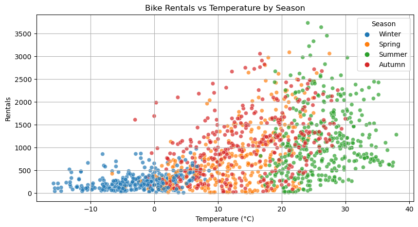

```python
# --- Visualization 2: Rentals by Temperature & Seasons ---
plt.figure(figsize=(10, 5))
sns.scatterplot(x='Temperature', y='RENTALS', data=df, hue='Season', alpha=0.7)
plt.title('Bike Rentals vs Temperature by Season')
plt.xlabel('Temperature (°C)')
plt.ylabel('Rentals')
plt.legend(title='Season')
plt.grid(True)
plt.show()

# This reveals that moderate temperatures (10-25°C) see higher rentals, especially in spring and summer.
```

#### Rentals by Temperature

This visualization examines the relationship between temperature and bike rental volume, offering insight into the conditions that drive user demand. The chart reveals a distinct pattern: rental activity increases as temperatures rise, reaching its highest levels between 20°C and 30°C. This suggests that moderate to warm weather encourages more bike usage. Conversely, demand drops when temperatures fall below 10°C or exceed 30°C, indicating that extreme cold or heat discourages ridership. These findings support the strategy of intensifying service availability and marketing efforts during favorable weather while scaling back during less ideal conditions.

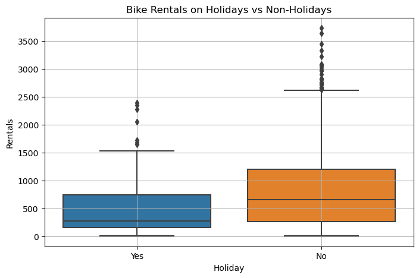

```python
# --- Visualization 3: Rentals on Holidays vs Non-Holidays ---
plt.figure(figsize=(8, 5))
sns.boxplot(x='Holiday', y='RENTALS', data=df)
plt.title('Bike Rentals on Holidays vs Non-Holidays')
plt.xlabel('Holiday')
plt.ylabel('Rentals')
plt.grid(True)
plt.show()

# Users tend to rent fewer bikes on holidays, likely due to reduced commuting.
```

#### Rentals by Day Type (Holiday vs Non-Holiday)

The boxplot reveals that bike rentals are generally lower on holidays compared to regular days. This pattern suggests that most usage is tied to daily commuting, which tends to decrease when people are off work. Understanding this behavior can help with demand forecasting and operational planning around public holidays.

###### **Key objectives** include identifying demand drivers, recognizing the role of weather, and proposing strategic recommendations based on data trends.